# xwMOOC 네트워크

메르스 감염 네트워크

## 1. 미디어 네트워크 데이터 [^1]

Katya Ognyanova 박사는 친절하게 네트워크 데이터에 대한 좋은 교육 내용과 함께 데이터도 인터넷에 공유해 주었다.

- 결점(Vertex, Node) 미디어 데이터: https://raw.githubusercontent.com/kateto/R-Network-Visualization-Workshop/master/Data/Dataset1-Media-Example-NODES.csv
- 연결선(Edge) 미디어 데이터: https://raw.githubusercontent.com/kateto/R-Network-Visualization-Workshop/master/Data/Dataset1-Media-Example-EDGES.csv

`tidyverse` 팩키지 `read_csv()` 함수를 통해 결점과 연결선 데이터를 불러오고 나서 이를 `igraph` 팩키지 `graph_from_data_frame()` 함수로 `igraph` 그래프 객체로 변환시킨다. 그리고 나서 `plot` 함수로 데이터가 정상적으로 들어왔는지 시각적으로 확인을 한다.

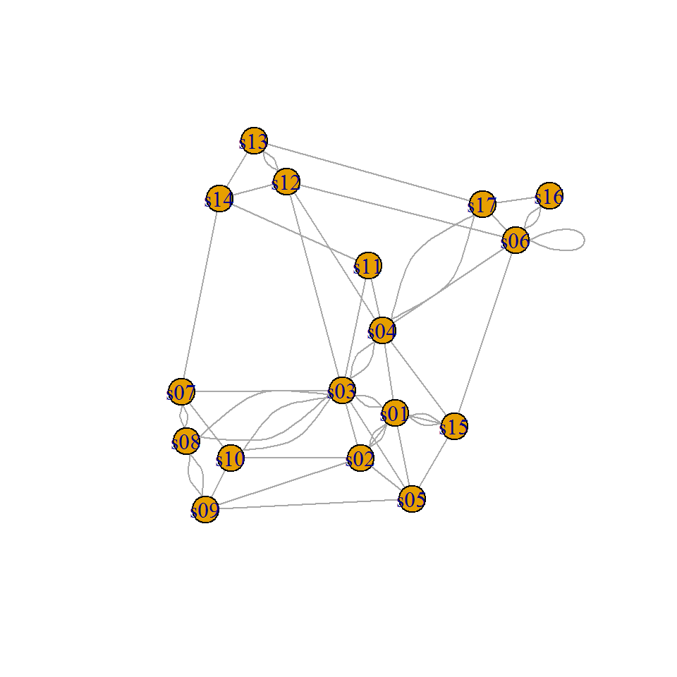

```r
# 0. 환경설정 --------------
library(tidyverse)
library(igraph)

# 1. 데이터 가져오기 --------------
## 1.1. 데이터 읽어들이기
media_vert <- read_csv("data/Dataset1-Media-Example-NODES.csv")

media_edge <- read_csv("data/Dataset1-Media-Example-EDGES.csv")

## 1.2. 네트워크 데이터 변환
media_ng <- graph_from_data_frame(d = media_edge, vertices = media_vert, directed = FALSE)

plot(media_ng)
```

## 2. 정적 네트워크 시각화

네트워크 데이터 시각화는 결국 **결점(Vertex, Node)**과 **연결선(Edge)**을 통해 다양한 시각적인 효과를 구현할 수 있다.

### 2.1. 결점 크기 조정

결점 크기를 조정하는 방법은 `vertex.size`에 `V(media_ng)$audience.size` 값을 넣어 크기를 반영할 수 있다. `media_vert` 데이터프레임에는 결점(Vertex) 속성이 다양하게 정의되어 있고, 연속형 `audience.size` 속성을 결점 크기로 지정한다.

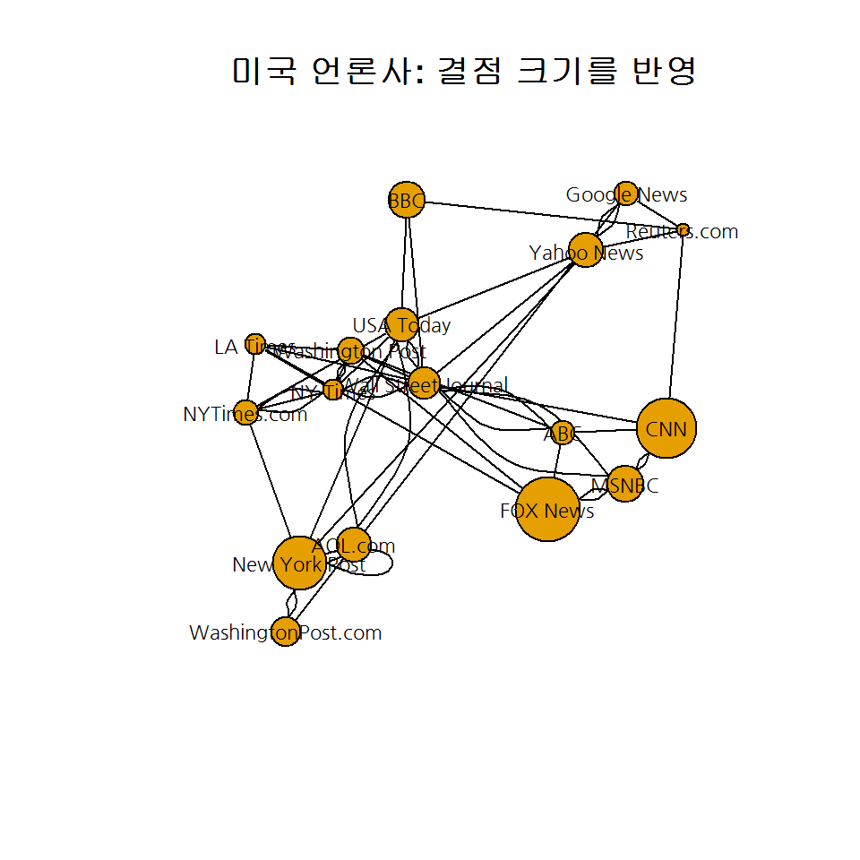

```r
# 3. 정적 네트워크 시각화 --------------
## 3.1. 결점(Vertex, Node) -----
### 3.1.1. 결점 크기 반영
# V(media_ng)[[1:5]]

plot(media_ng,
     vertex.label = V(media_ng)$media,
     vertex.label.color = "black",
     vertex.label.cex = 0.7,
     vertex.label.family="NanumGothic",
     vertex.size = V(media_ng)$audience.size / 2,
     edge.color = 'black',
     edge.arrow.size = .05,
     main = "미국 언론사: 결점 크기를 반영")
```

### 2.2. 결점 색상 조정

결점 색상를 조정하는 방법은 `vertex.color`에 `V(media_ng)$type.label` 값을 넣어 변형된 색상을 반영할 수 있다. `media_vert` 데이터프레임에는 결점(Vertex) 속성이 다양하게 정의되어 있고, 범주형 `type.label` 속성에 범주별로 색상을 지정한다. 이를 위해 먼저 `V(media_ng)$color`에 각 범주별로 색상을 지정한다.

`legend` 범례도 맞춰 동일하게 지정한다.

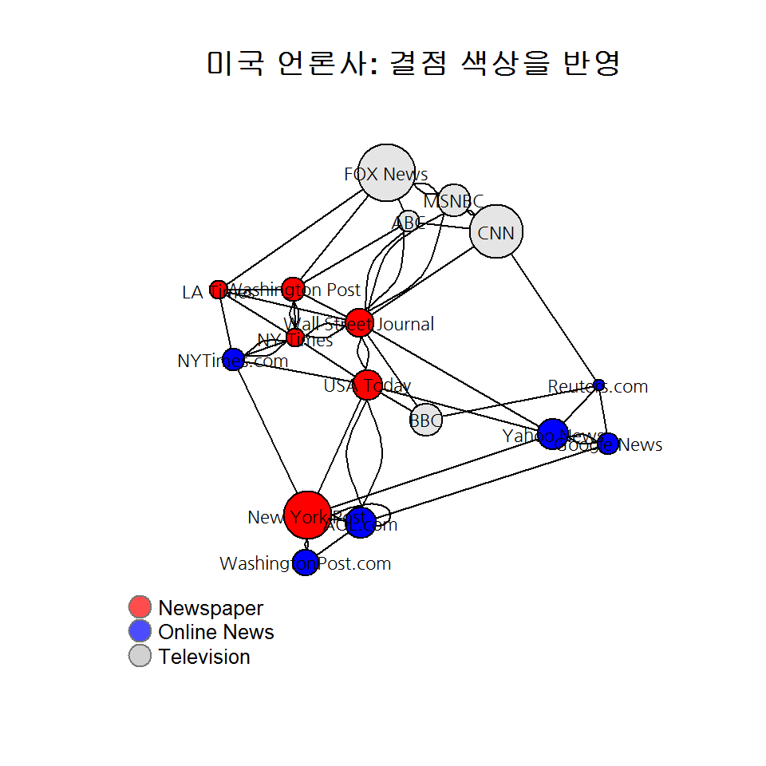

```r
### 3.1.2. 결점 색상 반영
### 색상 정의
# V(media_ng)$color <- case_when(V(media_ng)$media.type == 1 ~ "lightblue",
#                                V(media_ng)$media.type == 2 ~ "lightgreen",
#                                TRUE ~ "gray90")
V(media_ng)$color <- case_when(V(media_ng)$type.label == "Newspaper" ~ "red",
                               V(media_ng)$type.label == "Online" ~ "blue",
                               TRUE ~ "gray90")


plot(media_ng,
     vertex.label = V(media_ng)$media,
     vertex.label.color = "black",
     vertex.label.cex = 0.7,
     vertex.label.family="NanumGothic",
     vertex.size = V(media_ng)$audience.size / 2,
     # vertex.color = V(media_ng)$media.type,
     edge.color = 'black',
     edge.arrow.size = .05,
     main = "미국 언론사: 결점 색상을 반영")

### 범례 추가
media_color <- adjustcolor( c("red", "blue", "gray"), alpha=.7)

legend(x=-1.5, y=-1.1, c("Newspaper","Online News", "Television"), pch=21,
       col="#777777", pt.bg = media_color,
       pt.cex=2, cex=.8, bty="n", ncol=1)
```

### 2.3. 연결선 크기 조정

연결선 크기를 조정하는 방법은 `edge.width`에 `E(media_ng)$weight` 값을 넣어 연결선 선폭을 반영할 수 있다. `media_edge` 데이터프레임에는 연결선(Edge) 속성이 다양하게 정의되어 있고, 연속형 `weight` 속성을 연결선 선폭으로 지정한다.

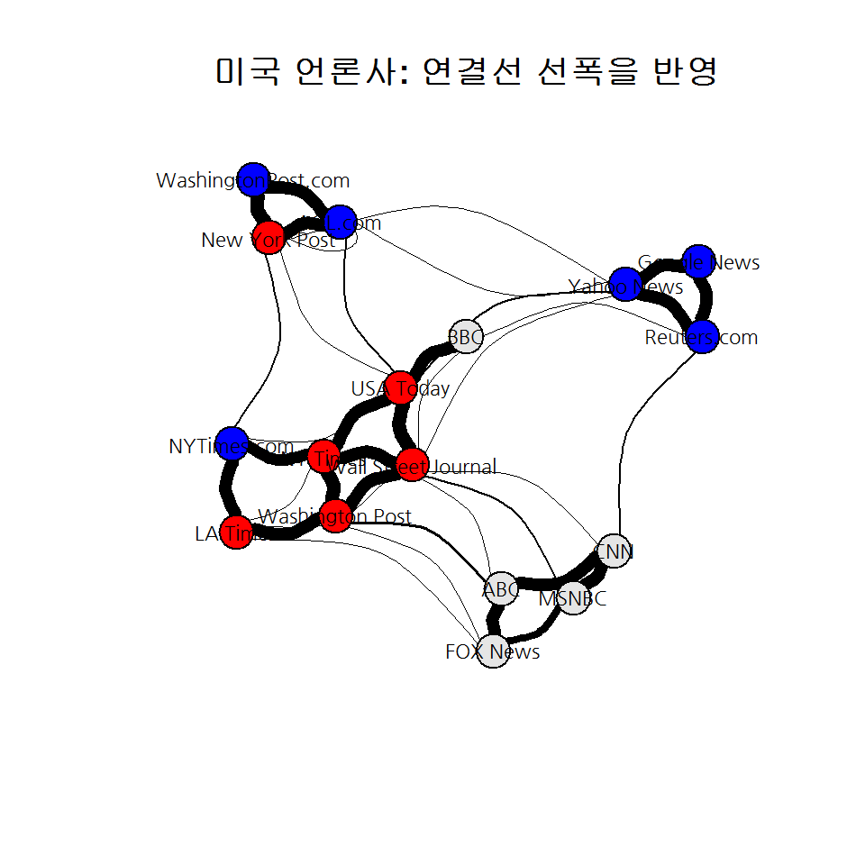

```r
## 3.2. 연결선(Edge) -----
### 3.2.1. 연결선 크기 반영
plot(media_ng,
     vertex.label = V(media_ng)$media,
     vertex.label.color = "black",
     vertex.label.cex = 0.7,
     vertex.label.family="NanumGothic",
     edge.width = E(media_ng)$weight / 3,
     edge.color = 'black',
     edge.curved=TRUE,
     edge.arrow.size = .05,
     main = "미국 언론사: 연결선 선폭을 반영")
```

### 2.4. 연결선 색상 조정

`legend` 범례도 맞춰 동일하게 지정한다.

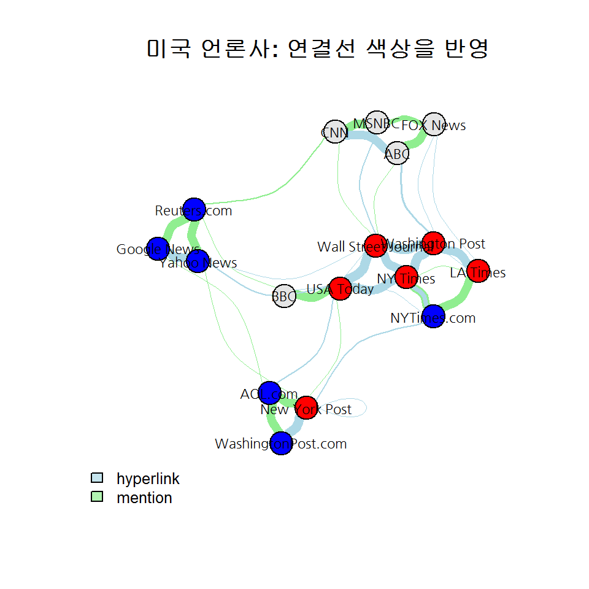

```r
### 3.2.2. 연결선 색상 반영
E(media_ng)$color <- case_when(E(media_ng)$type == "hyperlink" ~ "lightblue",
                                 E(media_ng)$type == "mention"   ~ "lightgreen")

plot(media_ng,
     vertex.label = V(media_ng)$media,
     vertex.label.color = "black",
     vertex.label.cex = 0.7,
     vertex.label.family="NanumGothic",
     edge.width = E(media_ng)$weight / 3,
     edge.color = E(media_ng)$color,
     edge.curved=TRUE,
     edge.arrow.size = .05,
     main = "미국 언론사: 연결선 색상을 반영")

### 범례 추가
edge_color <- adjustcolor( c("lightblue", "lightgreen"), alpha=.7)

legend(x=-1.5, y=-1.1, c("hyperlink","mention"),
       fill = edge_color, cex=.8, bty="n", ncol=1)
```

### 2.5. 결점 라벨 크기 및 색상 조정

`vertex.shape`을 “none”으로 설정해서 결점을 없애고 그 빈자리를 라벨로 채우는 방법이 때로는 도움이 된다.

라벨을 조정하는 방법은 `vertex.label`에 `vertex.label = V(media_ng)$media` 값을 넣어 라벨을 반영할 수 있다. `V(media_ng)$color`에 색상을 정의해서 `V(media_ng)$media.type` 미디어 유형 범주별로 색상을 달리 반영할 수 있다.

[figure not shown]

```r
## 3.3. 라벨 텍스트(Label) -----

V(media_ng)$color <- case_when(V(media_ng)$media.type == 1 ~ "red",
                               V(media_ng)$media.type == 2 ~ "blue",
                               TRUE ~ "orange")

plot(media_ng,
     vertex.shape = "none",
     vertex.label = V(media_ng)$media,
     vertex.label.cex = V(media_ng)$audience.size / mean(V(media_ng)$audience.size),
     vertex.label.dist = 0,
     vertex.label.color = V(media_ng)$color,
     vertex.label.family="NanumGothic",
     edge.width = E(media_ng)$weight / 3,
     edge.curved=TRUE,
     edge.arrow.size = .05,
     main = "미국 언론사: 결점대신 라벨")

### 범례 추가
media_color <- adjustcolor( c("red", "blue", "orange"), alpha=.7)

legend(x=-1.5, y=-1.1, c("Newspaper","Online News", "Television"), pch=21,
       col="#777777", pt.bg = media_color,
       pt.cex=2, cex=.8, bty="n", ncol=1)
```

## 3. 네트워크 데이터 조작

### 3.1. 네트워크 데이터 전처리

`simplify()` 함수를 통해 중복된 결점이나 반복되는 연결선을 제외하거나 중복되는 연결선에 대해서 간략화하도록 사전 작업을 진행한다. 이와 함께 격리된 결점(`V(media_ng)[igraph::degree(media_ng) == 0]`)에 대해서도 별도 작업을 할 수 있게 관리에 신경을 쓴다.

```r
# 2. 네트워크 데이터 전처리 --------------
## 2.1. 네트워크 간략화
media_sng <- simplify(media_ng, remove.multiple = TRUE, remove.loops = FALSE,
                      edge.attr.comb=c(weight="sum", type="ignore"))

## 2.2. 고립된 노드 처리...
media_isolated_ng <- V(media_ng)[igraph::degree(media_ng) == 0]
```

### 3.2. 불필요한 결점(Vertex) 제거

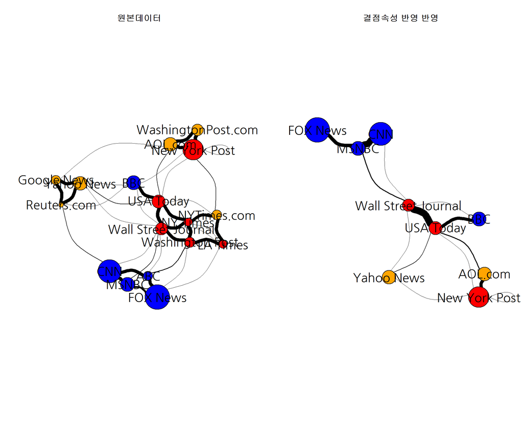

```r
# 3. 네트워크 결점(Vertex) 간략화 --------------
par(mfrow=c(1,2))
### 원본데이터
plot(media_ng,
     vertex.size = V(media_ng)$audience.size / 2,
     vertex.label = V(media_ng)$media,
     vertex.label.color = "black",
     vertex.label.cex = 1.7,
     vertex.label.family="NanumGothic",
     edge.width = E(media_ng)$weight / 3,
     edge.color = 'black',
     edge.curved=TRUE,
     edge.arrow.size = .05,
     main = "원본데이터")

### 중요하지 않은 결점 제거
media_vert_sng <- induced_subgraph(media_sng, which(V(media_sng)$audience.size >= 30))

plot(media_vert_sng,
     vertex.size = V(media_vert_sng)$audience.size / 2,
     vertex.label = V(media_vert_sng)$media,
     vertex.label.color = "black",
     vertex.label.cex = 1.7,
     vertex.label.family="NanumGothic",
     edge.width = E(media_vert_sng)$weight / 3,
     edge.color = 'black',
     edge.curved=TRUE,
     edge.arrow.size = .05,
     main = "결점속성 반영 반영")
```

### 3.3. 불필요한 연결선(Edge) 제거

연결선(edge) 속성값에 따라 유의미하지 않다(`weight <= 10`)고 판단되는 연결선을 `igraph::delete_edges` 함수를 통해 걷어내고 이를 추후 네트워크 시각화와 분석에 사용한다.

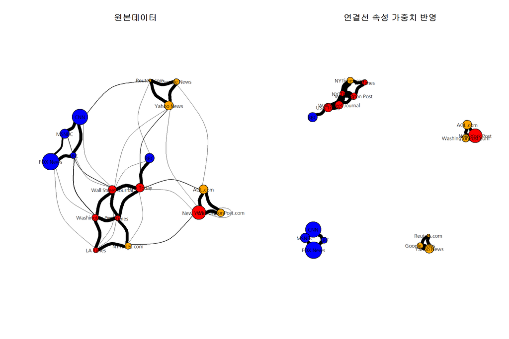

```r
# 4. 네트워크 연결선(Edge) 간략화 --------------
par(mfrow=c(1,2))

### 원본데이터
plot(media_ng,
     vertex.size = V(media_ng)$audience.size / 3,
     vertex.label = V(media_ng)$media,
     vertex.label.color = "black",
     vertex.label.cex = 0.7,
     vertex.label.family="NanumGothic",
     edge.width = E(media_ng)$weight / 3,
     edge.color = 'black',
     edge.curved=TRUE,
     edge.arrow.size = .05,
     # layout=  layout_nicely(media_sng),
     main = "원본데이터")

### 중요하지 않은 연결선 제거

media_edge_sng <- igraph::delete_edges(media_sng, E(media_sng)[[weight <= 10]])

plot(media_edge_sng,
     vertex.size = V(media_edge_sng)$audience.size / 3,
     vertex.label = V(media_edge_sng)$media,
     vertex.label.color = "black",
     vertex.label.cex = 0.7,
     vertex.label.family="NanumGothic",
     edge.width = E(media_edge_sng)$weight / 3,
     edge.color = 'black',
     edge.curved=TRUE,
     edge.arrow.size = .05,
     # layout=  layout_nicely(media_edge_sng),
     main = "연결선 속성 가중치 반영")
```

[^1]: [Ognyanova, K. (2017) Network visualization with R. Retrieved from www.kateto.net/network-visualization.](http://kateto.net/network-visualization)